# ST762-Asm02-2022-ID_2343672

Mave Danmei

07/04/2022

We would like to fit a good classifier a machine learning technique and predict a pumpkin seed type (Class) given its morphological features. PumpkinTrain.csv will be used to fit a classifier and we test it using PumpkinTest.csv.

```r
library(rpart); library(rpart.plot); library(rattle); library(gbm); library(randomForest);library(MASS);library(klaR)
```

### Q1 (a)

In the class, we learnt the three learning methods fortree based model and, they were a classification tree, random forestsand gradient boosting method. Our choice for performance measure is a precision and find the best classifier. [9 marks]

```r
#Setup random numbers
set.seed(1e5)
```

```r
pkin=read.csv("PumpkinTrain.csv",head=TRUE)
pk.test=read.csv("PumpkinTest.csv",head=TRUE)


pkin$Class=as.factor(pkin$Class)
pk.test$Class=as.factor(pk.test$Class)
```

#### Classification tree-pumpkin data

```r
pkin.cart0 <- rpart(Class~., data=pkin,method='class',cp=0.001)
pkin.cart0$cptable
```

```
##             CP nsplit rel error    xerror       xstd
## 1  0.736596737      0 1.0000000 1.0000000 0.02437360
## 2  0.012820513      1 0.2634033 0.2820513 0.01683069
## 3  0.011655012      3 0.2377622 0.2552448 0.01613256
## 4  0.004273504      4 0.2261072 0.2447552 0.01584396
## 5  0.003496503      7 0.2132867 0.2575758 0.01619547
## 6  0.002331002     13 0.1923077 0.2645688 0.01638161
## 7  0.002039627     19 0.1771562 0.2657343 0.01641226
## 8  0.001942502     23 0.1689977 0.2645688 0.01638161
## 9  0.001165501     26 0.1631702 0.2657343 0.01641226
## 10 0.001000000     27 0.1620047 0.2773893 0.01671314
```

```r
# Find the cp according to the 1se rules
cp.1se=max(pkin.cart0$cptable[pkin.cart0$cptable[,4]<sum(pkin.cart0$cptable[which.min(pkin.cart0$cptable[,4]),c(4,5)]),1])
```

```r
# prune the tree
pkin.prune0.opt=prune(pkin.cart0,cp=cp.1se)
```

```r
# predict classes and make confusion table , precision

pkin.pred0.opt=predict(pkin.prune0.opt,newdata=pk.test[,-13],type='class')

cart.mx=table(pkin.pred0.opt,pk.test$Class)
precision.cart=mean(diag(cart.mx)/rowSums(cart.mx))
precision.cart
```

```
## [1] 0.8574722
```

#### Random Forest–Pumpkin data

```r
set.seed(1234)
# Fit a random forest using default values

pkin.rf=randomForest(Class~.,data=pkin,importance=TRUE)
```

```r
# make confusion matrix, and precision

rf.mx=table(predict(pkin.rf,pk.test),pk.test$Class)
precision.rf=mean(diag(rf.mx)/rowSums(rf.mx))
precision.rf
```

```
## [1] 0.8696034
```

```r
#importance(pkin.rf)
```

#### Gradient boosting tree-Pumpkin data

```r
# Fit a boosting regression tree

set.seed(1234)

pkin=read.csv("PumpkinTrain.csv",head=TRUE)
pk.test=read.csv("PumpkinTest.csv",head=TRUE)

pk.gbm=gbm(Class~.,data = pkin,distribution = "bernoulli",shrinkage = 0.1,n.trees =500,cv.folds = 10)

# estimate the optimal number of boosting iteration using the
# cross validation

pk.gbm.perf=gbm.perf(pk.gbm,method="cv")
```

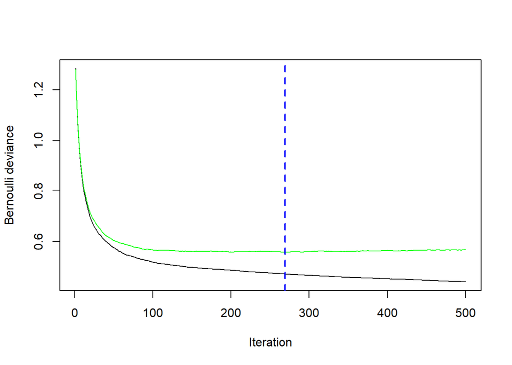

```r
# prediction with the opt number of trees
pkin.gbm.pred=predict(pk.gbm,newdata = pk.test,type = 'response')
```

```
## Using 269 trees...
```

```r
# pumpkin Class prediction is a range with the higtest probablity >0.5
pred.p=rep(0,dim(pk.test)[1])# declare pred.p as a vector

pred.p[which(pkin.gbm.pred>0.5)]=1

gbm.mx=table(pred.p,pk.test$Class)

precision.gbm=mean(diag(gbm.mx)/rowSums(gbm.mx))
precision.gbm
```

```
## [1] 0.8791966
```

#### Q1 (a) Answer: Gradient Boosting is preferred

```r
cbind(precision.cart,precision.gbm,precision.rf)
```

```
##      precision.cart precision.gbm precision.rf
## [1,]      0.8574722     0.8791966    0.8696034
```

#### Q1(b)

Answer: The most 4 important variables in the best model are as below: Eccentricity > Aspect_Ration> Compactness> Solidity

```r
# relative variable importance
pk.gbm.summary=summary.gbm(pk.gbm)
```

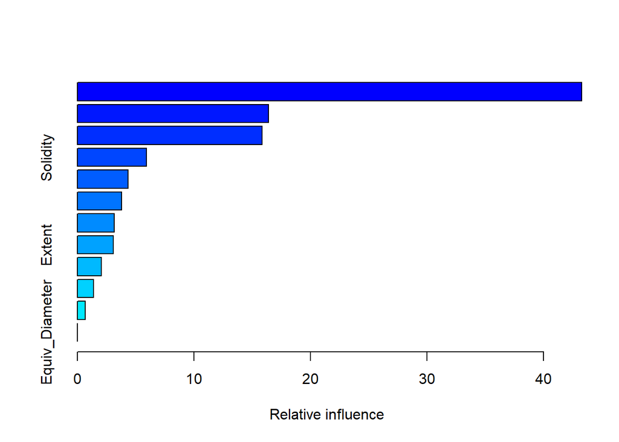

```r
pk.gbm.summary
```

```
##                                 var    rel.inf
## Eccentricity           Eccentricity 43.2857247
## Aspect_Ration         Aspect_Ration 16.4153565
## Compactness             Compactness 15.8593992
## Solidity                   Solidity  5.9472388
## Major_Axis_Length Major_Axis_Length  4.3403016
## Minor_Axis_Length Minor_Axis_Length  3.8177786
## Roundness                 Roundness  3.1586597
## Extent                       Extent  3.0787991
## Area                           Area  2.0453438
## ConvexArea               ConvexArea  1.3930808
## Perimeter                 Perimeter  0.6583172
## Equiv_Diameter       Equiv_Diameter  0.0000000
```

#### Q1 (c)

QDA–Pumpkin data write 3 different features between Urgup Sivrisi & Cere evelik

##### Answer:

##### Eccentricity:

Ürgüp Sivrisi mean is:0.8288922 C˛erc˛evelik mean is 0.8940883

##### Aspect_Ration:

Ürgüp Sivrisi mean is 1.815177 C˛erc˛evelik mean is 2.281861

##### Compactness:

Ürgüp Sivrisi mean is 0.7426684 C˛erc˛evelik mean is 0.6635621

These features are profound different.

```r
# Fit the QDA for the train data

pkin=read.csv("PumpkinTrain.csv",head=TRUE)
pk.test=read.csv("PumpkinTest.csv",head=TRUE)
# pkin$Class=as.factor(pkin$Class)
# pk.test$Class=as.factor(pk.test$Class)

pkin.qda=qda(Class~.,pkin)
pkin.qda
```

```
## Call:
## qda(Class ~ ., data = pkin)
##
## Prior probabilities of groups:
##         0         1
## 0.5097143 0.4902857
##
## Group means:
##       Area Perimeter Major_Axis_Length Minor_Axis_Length ConvexArea
## 0 78499.57  1088.966          425.5987          235.3710   79364.37
## 1 82920.64  1174.078          489.3251          215.6962   83749.92
##   Equiv_Diameter Eccentricity  Solidity    Extent Roundness Aspect_Ration
## 0       315.3287    0.8288922 0.9890686 0.7076281 0.8289405      1.815177
## 1       323.5120    0.8940883 0.9899923 0.6778000 0.7516203      2.281861
##   Compactness
## 0   0.7426684
## 1   0.6635621
```

```r
qda.pred=predict(pkin.qda,pk.test)

qda.mx=table(qda.pred$class,pk.test$Class)
```

#### Q1(d)

##### Answer:

precision of gdm > precision of qda

```r
precision.qda=mean(diag(qda.mx)/rowSums(qda.mx))
precision.qda
```

```
## [1] 0.871001
```

#### Q2 (a)

A linear regrsn using a b-spline of the order 4 is considered and , a range of possible numbre of knots is [0,20]

Find the number of knots minimizing the cross validation error using 10 folders.

##### Answer:

No_of_knots is 6, 6 knots are preferred

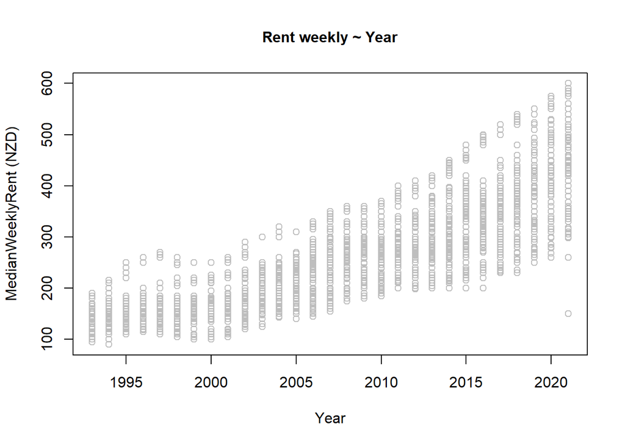

```r
trainRt=read.csv('Rent.csv',header = TRUE)
plot(trainRt$Year,trainRt$MRent,col="grey",main="Rent weekly ~ Year",xlab = "Year",ylab = "MedianWeeklyRent (NZD)",cex.main=1)
```

```r
library(splines)
# vector of no of knots
year.mse.bs=v=c(0:20)

ii=rep(c(1:10),554)
ii=ii[1:nrow(trainRt)]

for(j in 1:length(v)){
  for(i in 1:max(ii)){

    t.bs=bs(trainRt$Year[ii!=i],df=3+v[j])

    t.test.bs=predict(t.bs,trainRt$Year[ii==i])
    trainData=data.frame(Year=t.bs,MRent=trainRt$MRent[ii!=i])
    testData=data.frame(Year=t.test.bs,MRent=trainRt$MRent[ii==i])

    pre.t.bs=predict(lm(MRent~.,trainData),testData)
  #MSE
  year.mse.bs[j]=year.mse.bs[j]+mean((testData$MRent-pre.t.bs)^2)


  }# 10 folds
}# knots
# plot(v,year.mse.bs,'o',ylab='MSE',xlab='Number of knots')

# knots number for minimizing the cv
opt.knot=v[which.min(year.mse.bs)]
opt.knot
```

```
## [1] 6
```

#### Q2 (b)

2. Using your choice of number of knots in (a), plot the fitted median weekly rent against years with confidence intervals. [3 marks]

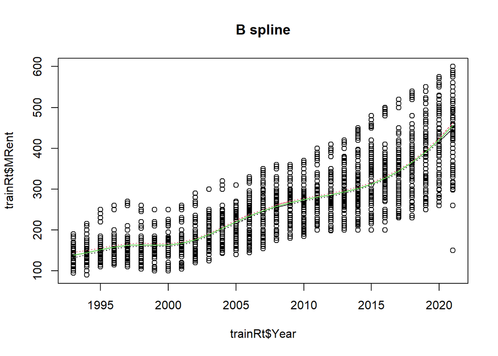

```r
pre.t.bs=predict(lm(MRent~bs(Year,df=3+6),data=trainRt),newdata=trainRt,interval = 'confidence')

plot(trainRt$Year,trainRt$MRent,main = 'B spline')
matlines(trainRt$Year,pre.t.bs,lty = c(1,3,3),col=c(3,1,2))
```

#### Q2 (c)

3. Using your choice of number of knots in (a), fit regression models targeting the 0.1, 0.5 and 0.9 quantiles of median weekly rent. i.e., quantile regression. Display the expected 0.1, 0.5 and 0.9th quantiles of median weekly rent against years in a single figure. [3 marks]

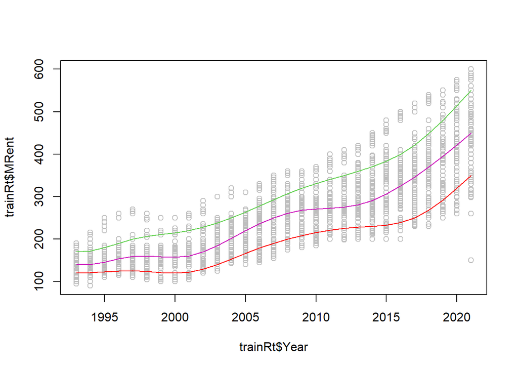

```r
library(quantreg);library(graphics);library(stats)
library(glmnet);library(MASS)
pre.rq10.bs=predict(rq(MRent~bs(Year,df=3+6,Boundary.knots = range(1990,2050)),data=trainRt,tau=0.1),newdata=trainRt)

pre.rq50.bs=predict(rq(MRent~bs(Year,df=3+6,Boundary.knots = range(1990,2050)),data=trainRt,tau=0.5),newdata=trainRt)


pre.rq90.bs=predict(rq(MRent~bs(Year,df=3+6,Boundary.knots = range(1990,2050)),data=trainRt,tau=0.9),newdata=trainRt)

plot(trainRt$Year,trainRt$MRent,col='grey');
lines(trainRt$Year,pre.rq10.bs,col='red')
lines(trainRt$Year,pre.rq50.bs,col=6)
lines(trainRt$Year,pre.rq90.bs,col=3)
```

#### Q2 (d)

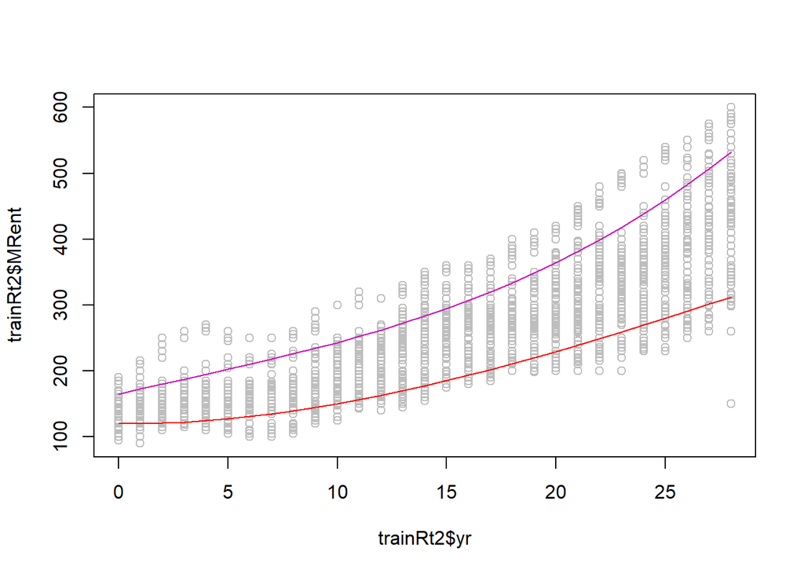

```r
trainRt2=data.frame(MRent=trainRt$MRent,yr=as.numeric(trainRt$Year)-1993)

pred.rq10.py=predict(rq(MRent~poly(yr,3,raw=TRUE),data = trainRt2 ,tau=0.1),newdata=trainRt2)

pred.rq90.py=predict(rq(MRent~poly(yr,3,raw=TRUE),data=trainRt2,tau=0.9),newdata=trainRt2)


plot(trainRt2$yr,trainRt2$MRent,col='grey');
lines(trainRt2$yr,pred.rq10.py,col='red')
lines(trainRt2$yr,pred.rq90.py,col=6)
```

#### Q2 (e)

5. Among the two 0.1 and 0.9 quantile regressions in (b)-bSpline-6-knots and (d)-poly-3-degree, which one give a more reliable quantile estimate over the years? Answer the question using a suitable quality measure of quantile estimates per year. [4 marks]

##### Answer:

```r
# avg rent per year
avg.trainRt=aggregate(trainRt["MRent"],trainRt[c("Year")],mean)
avg.trainRt2=aggregate(trainRt2["MRent"],trainRt2[c("yr")],mean)


# poly and quantile regrsn
pred.rq10.py=predict(rq(MRent~poly(yr,3,raw=TRUE),data = avg.trainRt2 ,tau=0.1),newdata=avg.trainRt2)

pred.rq90.py=predict(rq(MRent~poly(yr,3,raw=TRUE),data=avg.trainRt2,tau=0.9),newdata=avg.trainRt2)

# bs and quantile regrsn

pre.rq10.bs=predict(rq(MRent~bs(Year,df=3+6,Boundary.knots = range(1990,2050)),data=avg.trainRt,tau=0.1),newdata=avg.trainRt)

pre.rq90.bs=predict(rq(MRent~bs(Year,df=3+6,Boundary.knots = range(1990,2050)),data=avg.trainRt,tau=0.9),newdata=avg.trainRt)

# the proportion of under estimate prediction

under.Est=cbind(mean(avg.trainRt2$MRent>pred.rq10.py)
,mean(avg.trainRt2$MRent>pred.rq90.py)
,mean(avg.trainRt$MRent>pre.rq10.bs)
,mean(avg.trainRt$MRent>pre.rq90.bs)
)
colnames(under.Est)=c('rq0.1 poly','rq0.9 poly','rq0.1 bs','rq0.9 bs')

under.Est
```

```
##      rq0.1 poly rq0.9 poly  rq0.1 bs  rq0.9 bs
## [1,]  0.8965517  0.1034483 0.7586207 0.1034483
```